# Course Project 1

Borisa Sabljic

October 24, 2016

# Introduction

This assignment makes use of data from a personal activity monitoring device. This device collects data at 5 minute intervals through out the day. The data consists of two months of data from an anonymous individual collected during the months of October and November, 2012 and include the number of steps taken in 5 minute intervals each day.

# Data

The data for this assignment can be downloaded from the course web site:

Dataset: Activity monitoring data [52K]

The variables included in this dataset are:

- steps: Number of steps taking in a 5-minute interval (missing values are coded as 𝙽𝙰)
- date: The date on which the measurement was taken in YYYY-MM-DD format
- interval: Identifier for the 5-minute interval in which measurement was taken

The dataset is stored in a comma-separated-value (CSV) file and there are a total of 17,568 observations in this dataset.

# Loading and preprocessing the data

The first step in the project, after downloading the data and unpacking it to the local file system, is to read it into R using read.csv; stringsAsFactors is set to FALSE so that dates are not factors but strings that will be converted to dates later.

```r
activity  <- read.csv("activity.csv", stringsAsFactors = F)
```

# What is mean total number of steps taken per day?

Using `dplyr` library is going to be convenient. First, I loaded the `dplyr` library.

```r
suppressMessages(library(dplyr))
library("dplyr")
```

The data contains NA values. I created a new dataset with NA values removed from it. `complete.cases` method returned only those days for which step counts were recorded.

```r
complete_days_only <- activity[complete.cases(activity), ]
```

The analysis is peformed useing the `group_by` and `summarise` functions from `dplyr`. The sum can be calculated using `summarise` once the data has been organized by date using `group_by`

```r
step_summary  <-  complete_days_only %>%
                  group_by(date) %>%
                  summarise(daily_step_count = sum(steps))
```

Next I made a plot for total number of steps taken per day.

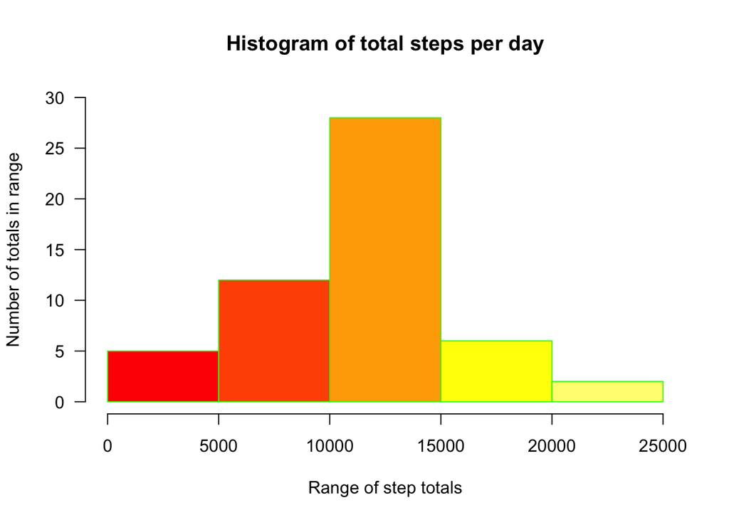

```r
hist(step_summary$daily_step_count,
    main = "Histogram of total steps per day",
    xlab = "Range of step totals",
    ylab = "Number of totals in range",
    border = "green",
    col = heat.colors(5),
    las = 1,
    ylim = c(0, 30))
```

Next I calculated and reported mean and median of total number of steps taken per day.

```r
sprintf("MEAN of the total number of steps taken per day: %s", mean(step_summary$daily_step_count))
```

```
## [1] "MEAN of the total number of steps taken per day: 10766.1886792453"
```

```r
sprintf("MEDIAN of the total number of steps taken per day: %s", median(step_summary$daily_step_count))
```

```
## [1] "MEDIAN of the total number of steps taken per day: 10765"
```

# What is the average daily activity patern?

What was the average number of steps taken in each interval within each recorded interval across all days in each of the two months? I used `group_by` for each interval and then took the mean of the steps in each interval.

```r
x  <- complete_days_only %>%
      group_by(interval) %>%
      summarise(avg_interval = mean(steps))
```

I ploted the results to see the distribution of the averages.

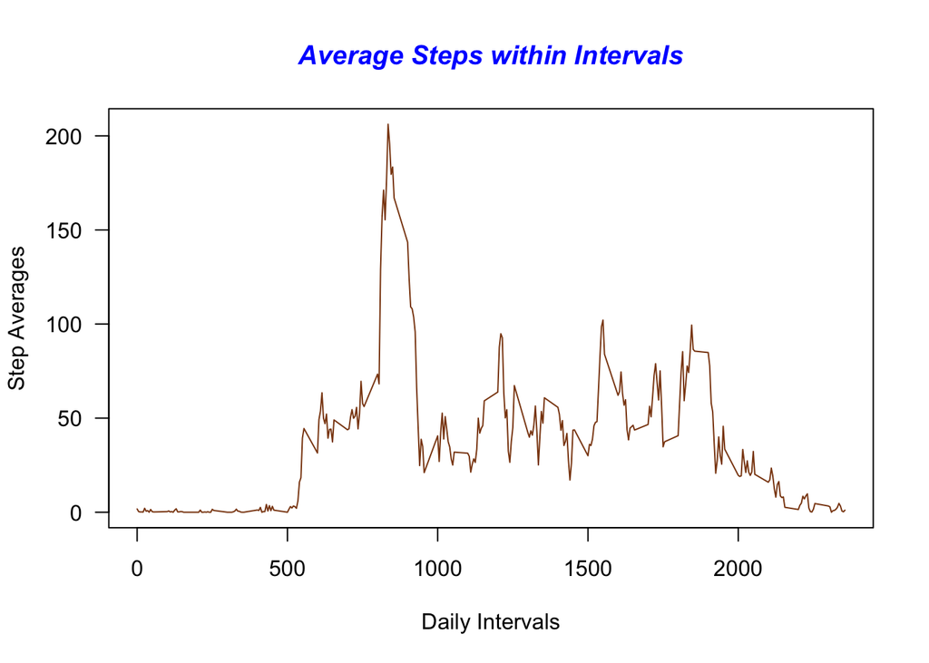

```r
plot(x$interval,
     x$avg_interval,
     type = "l",
     las = 1,
     col = "chocolate4",
     main = "Average Steps within Intervals",
     col.main = "blue",
     font.main = 4,
     xlab = "Daily Intervals",
     ylab = "Step Averages"
     )
```

The `which.max` function gave the interval with highest number of average steps

```r
x[which.max(x$avg_interval), ]
```

```
## Source: local data frame [1 x 2]
##
##   interval avg_interval
##      (int)        (dbl)
## 1      835     206.1698
```

# Inputing Missing Values

The number of NA values was calculated using the `nrow` function against both the original and reduced datasets.

```r
nrow(activity)
```

```
## [1] 17568
```

```r
nrow(complete_days_only)
```

```
## [1] 15264
```

The number of missing observations is the difference between the two, or 2304.

I used a simple random number generator to impute values for missing values observations. Using `set.seed` resulted in the same set of integers being produced for subsequent runs and supported the concept of reproducible research. The max value is divided by 10 provide reasonable scale to these values, which can get quite large and skew the results in a different way than the missing values can.

```r
set.seed(1234)
z  <- floor(runif(nrow(activity),
                  min = min(activity$steps, na.rm = T),
                  max = max(activity$steps, na.rm = T)/10))
```

Next the indices of the missing values are determined. The use of a separate vector to hold these results rather than include them inline in the mutation code is done for readability.

```r
w  <- which(is.na(activity$steps))
```

Finally, the missing values for the number of steps are replaced with corresponding entries from the integer vector.

```r
activity$steps[w]  <- z[w]
```

How does imputing values for missing data affect the results obtained earlier with the reduced dataset? The same calculations for total steps per day can be calculated against the augmented dataset and the results plotted via a histogram.

```r
complete_data  <- activity %>%
                  group_by(date) %>%
                  summarise(daily_step_count = sum(steps))
```

And here is the plot:

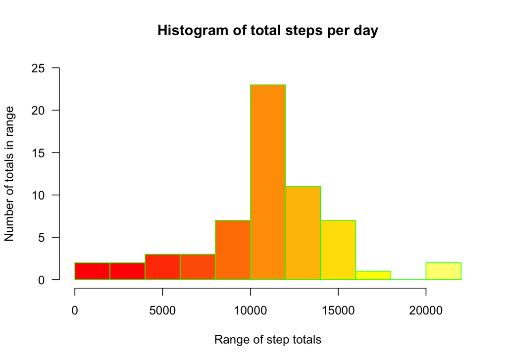

```r
hist(complete_data$daily_step_count,
    breaks = 10,
    main = "Histogram of total steps per day",
    xlab = "Range of step totals",
    ylab = "Number of totals in range",
    border = "green",
    col = heat.colors(12),
    las = 1,
    ylim = c(0, 25))
```

Once again, the mean and median can be easily calculated from the daily totals, and the mean of all the steps over the two-month period is 10858.38 while the median is 11196. The imputed data had a negligible affect on both the mean and the median calculated values. The data did, however, produce a gap in recorded values for the range between 18000 and 20000.

# Are there differences in activity patterns between weekdays and weekends?

To answer this question, the date variable has its values converted to dates.

```r
activity$date <- as.POSIXct(activity$date)
```

In order to separate the data into weekday and weekend subsets for analysis, the date variable is input to the `weekdays` method and that output is checked against a vector of weekend day names. The appropriate text is added as a new column to the dataframe. This column is then converted to a factor using the `as.factor` method.

```r
activity$dayType  <- ifelse(weekdays(activity$date) %in% c("Saturday", "Sunday"), "weekend", "weekday")
activity$dayType  <- as.factor(activity$dayType)
```

To prepare the data for plotting, the dataset with imputed values is organized first by dayType (weekday, weekend) and then by interval. A sum of the steps recorded within those time intervals for each dayType is then computed.

```r
q  <- activity %>%
      group_by(dayType, interval) %>%
      summarise(daily_step_count = sum(steps))
```

I created a time series plot using the lattice package so that the independent/dependent variables can be conditioned by the factor variable dayType.

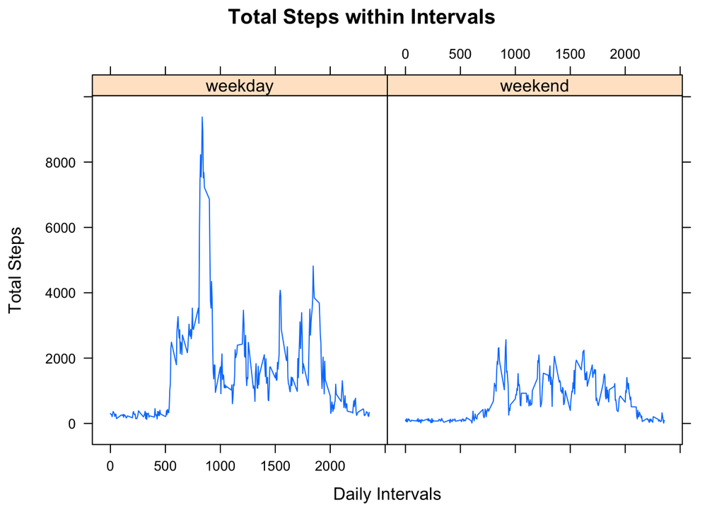

```r
library(lattice)
with(q,
      xyplot(daily_step_count ~ interval | dayType,
      type = "l",
      main = "Total Steps within Intervals",
      xlab = "Daily Intervals",
      ylab = "Total Steps"))
```